# Derivation of a prognostic signature for renal carcinoma

Anna Bird

### SCRIPT OVERVIEW

The goal of this analysis is to derive a transcriptomic signature that predicts disease outcome for Renal Carcinoma patients. Voom/Limma is used here to derive abnormally expressed genes in a comparison of tumor vs. normal associated tissue (NAT). A survival model then elucidates which abnormally expressed DEG predict patient outcome, using a combined outcome metric (patient survival or days to last follow-up’). The resulting prognostic signature includes a list of genes with well-known associations to tumor progression, including TGFbeta & Wnt signaling pathways.

### INSTRUCTIONS

1) Make sure GDC client is installed on your machine – https://gdc.cancer.gov/access-data/gdc-data-transfer-tool

2) OPTIONAL: Input a file path for your downloaded transcriptomic data in the first code chunk below. Total downloaded data are 156MB.

3) Run this script (click “Knit” above) (takes ~10min to run on my laptop)

### ANALYSIS OUTLINE

Analysis Stage 1 - Assess data structure and design Limma model

A) SET UP QUERY for human Kidney Renal Clear Cell Carcinoma (KIRC) transcriptomic data from the GDC (TCGA) database, generated using both tumor samples and normal associated tissue (NAT) [<https://portal.gdc.cancer.gov/projects/TCGA-KIRC>](https://portal.gdc.cancer.gov/projects/TCGA-KIRC)

B) CLINICAL METADATA PROFILED to look for any confounders that need to be corrected for in the final limma model design. For example, tumor and NAT samples showed differences in their tumor stage profile, meaning tumor stage needed to be corrected for as a source of transcriptomic variation.

C) VOOM NEEDED? - Calculate library size variance (e.g. determine whether to use VOOM). This is done by first setting up a preliminary design matrix, normalizing the data, and ploting the library distributions & normalization correction factors.

Analysis Stage 2 - Determine which genes show abnormal expression in cancer & of these, which predict survival?

D) RE-RUN QUERY with a filtered samples list (some samples with small lib size were removed)

E) LIMMA/VOOM were used to obtain DEG (NAT vs. tumor)

F) TUMOR STRATIFICATION NEEDED? - Correlation heat mapping and PCA were used to visualize the number of major sample populations & and assess whether tumor sample stratification might be appropriate (no clear basis for stratification was observed).

G) SURVIVAL MODEL - Top abnormally expressed genes (DEG from NAT vs. tumor), were used to determine which genes would predict survival, yielding a prognostic gene signature

OPTIONAL: Input your own file path for data download. GDC KIRC transcriptomic counts will be directed to this folder:

```r
target_directory <- file.path(getwd(), "GDCdata")
```

Once the directory above has been set, run all code: (click “Knit” above ). You may need to install BioC packages if you don’t already have them.

```r
packages <- unique(c("ape", "chroma","colormap","corrplot","cowplot","data.table","datasets","devtools","downloader","Ecdat","embed","epiR","esquisse","extrafont","extrafontdb","factoextra","FactoMineR","flexdashboard","gapminder","ggforce","ggfortify","ggplot2","ggpointdensity","ggpubr","ggrepel","ggsci","ggvis","ggh4x","gmodels","grid","gridBase","gridExtra","gtable","gtools","GGally","heatmaply","hflights","Hmisc","here","hms","jcolors","knitr","kableExtra","Lahman","lattice","lsr","lubridate","Matrix","mlbench","MASS","nycflights13","patchwork","pheatmap","plyr","pzfx","rafalib","RColorBrewer","readxl","remotes","reshape","reshape2","rio","rsvd","scales","sciplot","Seurat","shiny","stringr","stringi","skimr","tidyr","tidyselect","tidyverse","tm","ursa","VennDiagram","viridis","writexl","here","RColorBrewer","repurrrsive","ggridges","ggthemes","tm","SnowballC","wordcloud","e1071","vroom","tidylog","janitor","lubridate","glue","tsibble","tidytext","tidymodels","rstatix","ggplotify","dr4pl","tidyverse","sandwich","lmtest","drc","tidymodels","grid","gridExtra","lattice","parsnip","aod","ggpubr","knitr","patchwork","rlang","rstatix","elisar","ursa","hrbrthemes","ggstatsplot","RPostgreSQL","scclusteval","xlsx","TCGAbiolinks","limma","edgeR","glmnet","factoextra","FactoMineR","caret","SummarizedExperiment","gplots","survival","survminer","RColorBrewer","gProfileR","genefilter", "TCGAbiolinks", "GenomicDataCommons", "CGPfunctions"))

# BiocManager::install("BioinformaticsFMRP/TCGAbiolinks")     # For bioC packages
# BiocManager::install("GenomicDataCommons")

package.check <- lapply(
  packages,
  FUN = function(x) {
    if (!require(x, character.only = TRUE)) {
      install.packages(x, dependencies = TRUE)
      library(x, character.only = TRUE)
    }
  }
)

theme_set(theme_bw(base_family = "Helvetica"))
theme_update(strip.background = element_rect(color="white", fill="#FFFFFF", size=0),
          strip.text = element_text(colour = 'black', size = 12, face = "bold", hjust = 0),
          plot.tag = element_text(color = "ivory", hjust = 1, size = 8))

knitr::opts_chunk$set(error = FALSE, message = FALSE, warning = FALSE)
```

### Analysis Stage 1 - Assess data structure and design Limma model

#### A) SET UP QUERY

```r
query = GDCquery(
  project = "TCGA-KIRC",
  data.category = "Transcriptome Profiling",
  experimental.strategy = "RNA-Seq",
  workflow.type = "HTSeq - Counts",
  sample.type = c("Primary Tumor", "Solid Tissue Normal"),  # tumor and NAT
  access = "open",
  legacy = FALSE)

GenomicDataCommons::status()
```

```
## $commit
## [1] "b49b90e1318040f447906940f3dff145809d9ea0"
##
## $data_release
## [1] "Data Release 31.0 - October 29, 2021"
##
## $status
## [1] "OK"
##
## $tag
## [1] "3.0.0"
##
## $version
## [1] 1
```

```r
GDCdownload(query,
  method = "api",
  directory = target_directory)

kirc_res = getResults(query)

kirc_res$is_ffpe %>% unique()                      # are ffpe samples present?
```

```
## [1] NA
```

```r
# Prepare expression series matrix from downloaded files
KIRC_data <- GDCprepare(query, directory = target_directory)
```

[output not shown]

[output cut: 548 more lines]

[output not shown]

Take a look @ the series matrix

```r
KIRCMatrix <- assay(KIRC_data)
KIRCMatrix[1:10, 1:10]
```

```
##                 TCGA-A3-3382-01A-02R-1325-07 TCGA-CZ-5453-11A-01R-1503-07
## ENSG00000000003                         4850                        16515
## ENSG00000000005                           26                           24
## ENSG00000000419                         1534                         2386
## ENSG00000000457                         1003                         1886
## ENSG00000000460                          307                          218
## ENSG00000000938                          703                          635
## ENSG00000000971                         7081                         2669
## ENSG00000001036                         2629                         6436
## ENSG00000001084                         2233                         2464
## ENSG00000001167                         1100                         2530
##                 TCGA-B0-5120-01A-01R-1420-07 TCGA-B0-5119-01A-02R-1420-07
## ENSG00000000003                         2881                         3130
## ENSG00000000005                           10                          253
## ENSG00000000419                         1378                         1365
## ENSG00000000457                          813                          842
## ENSG00000000460                          245                          186
## ENSG00000000938                         1053                         1016
## ENSG00000000971                         8193                         1476
## ENSG00000001036                         4052                         3367
## ENSG00000001084                         3371                         3133
## ENSG00000001167                         1548                         1396
##                 TCGA-B4-5834-01A-11R-1672-07 TCGA-BP-4763-01A-01R-1289-07
## ENSG00000000003                         4571                          862
## ENSG00000000005                           34                           21
## ENSG00000000419                         1675                         2159
## ENSG00000000457                         1090                          757
## ENSG00000000460                          251                          235
## ENSG00000000938                          987                          432
## ENSG00000000971                         5301                        22545
## ENSG00000001036                         4677                         3940
## ENSG00000001084                         3670                         5021
## ENSG00000001167                         1766                         1682
##                 TCGA-A3-3324-01A-02R-1325-07 TCGA-CJ-5675-01A-11R-1541-07
## ENSG00000000003                         2606                         3135
## ENSG00000000005                            2                           37
## ENSG00000000419                         1381                         1274
## ENSG00000000457                          830                          898
## ENSG00000000460                          310                          222
## ENSG00000000938                         1026                         1369
## ENSG00000000971                         1316                         2164
## ENSG00000001036                         6074                         3574
## ENSG00000001084                         4159                         1503
## ENSG00000001167                         1420                         1695
##                 TCGA-B2-3924-01B-03R-A277-07 TCGA-BP-4977-01A-01R-1334-07
## ENSG00000000003                          662                         5404
## ENSG00000000005                           23                          312
## ENSG00000000419                          449                         1471
## ENSG00000000457                          633                         1278
## ENSG00000000460                          359                          356
## ENSG00000000938                          379                         1041
## ENSG00000000971                         1484                         3807
## ENSG00000001036                         1073                         7086
## ENSG00000001084                         1576                         3236
## ENSG00000001167                         1290                         2131
```

#### B) CLINICAL METADATA PROFILED

Info on GDC metadata: https://docs.gdc.cancer.gov/Data_Dictionary/viewer/#?view=table-definition-view&id=demographic&anchor=age_at_index

Looking for potential confounders in the metadata, e.g. is the tumor variable “longest_dimension” (size) greater in NAT samples compared to tumor samples? Would such a difference in tumor growth need to be corrected for in the upcoming diff. expr. analysis between NAT vs tumor?

– Plotting continuous variables –

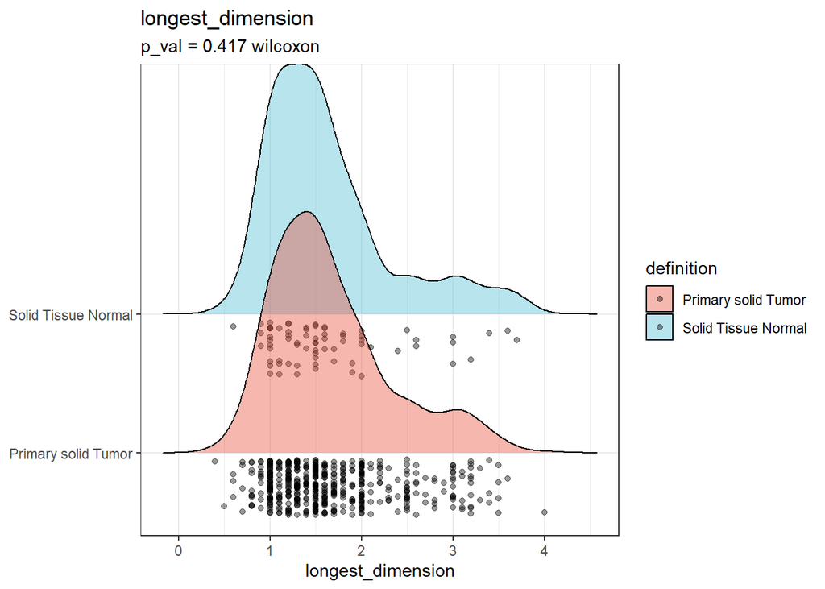

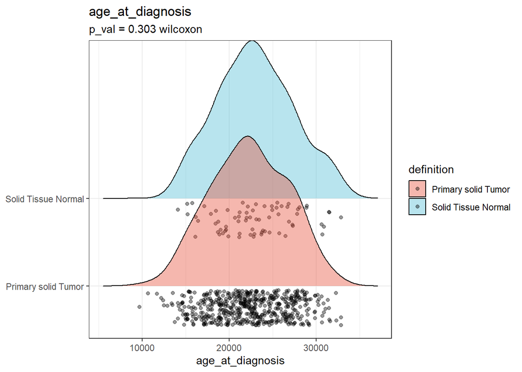

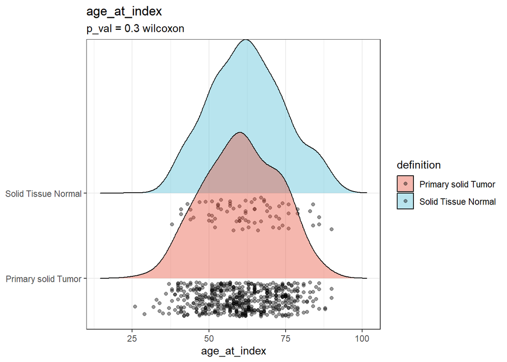

```r
contin_vars <- c("longest_dimension", "age_at_diagnosis", "age_at_index")

CV_plot <- function(VAR) {

  WT <- tidy(wilcox.test(KIRC_data@colData[[VAR]] ~ definition, KIRC_data@colData))
  WT_p <- WT$p.value
  WT_test <- "wilcoxon"

  df <- KIRC_data@colData %>%
    as_tibble()

  ggplot(df, aes_string(x = VAR, y = factor(df$"definition"),
                group = "definition",
                fill = "definition")) +
  geom_density_ridges(jittered_points = TRUE,
                position = "raincloud",
                alpha = 0.4,
                color = "black") +
    scale_fill_npg() +
    labs(y = NULL, title = paste(VAR), subtitle = paste("p_val =", round(WT_p, 3), WT_test))
  }

map(contin_vars, ~ CV_plot(.x))
```

Assessment: age_at_index, age_at_diagnosis, and tumor size (longest_dimension) are not signficantly different between primary sold tumor and solid tissue normal (NAT).

Looking for potential confounders in the metadata

– Plotting discrete variables –

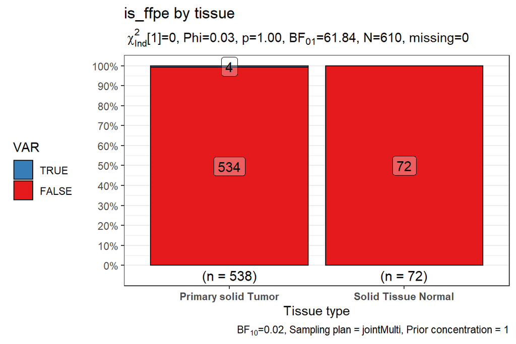

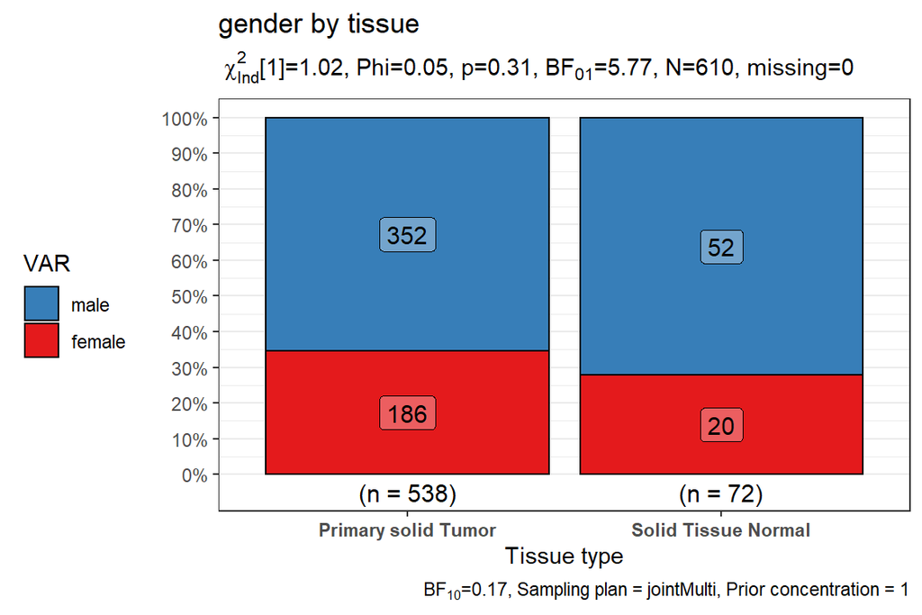

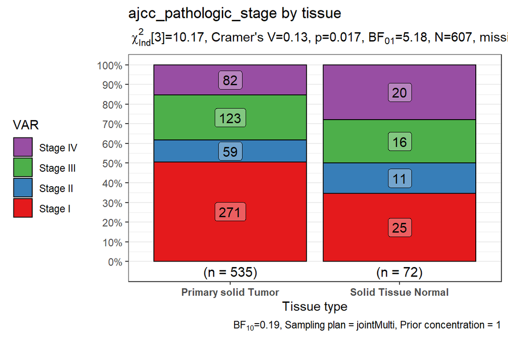

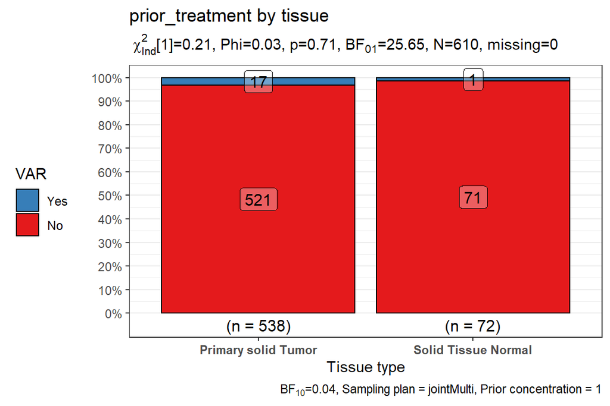

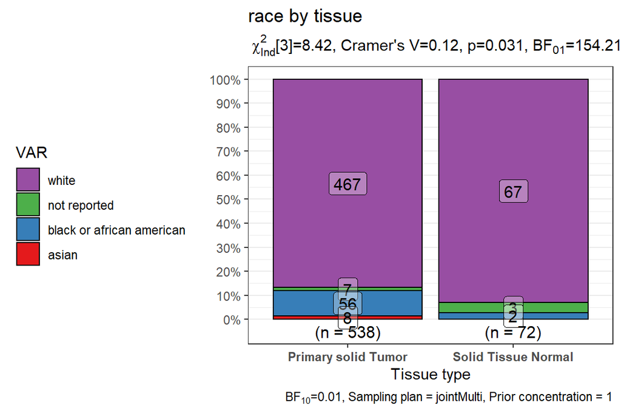

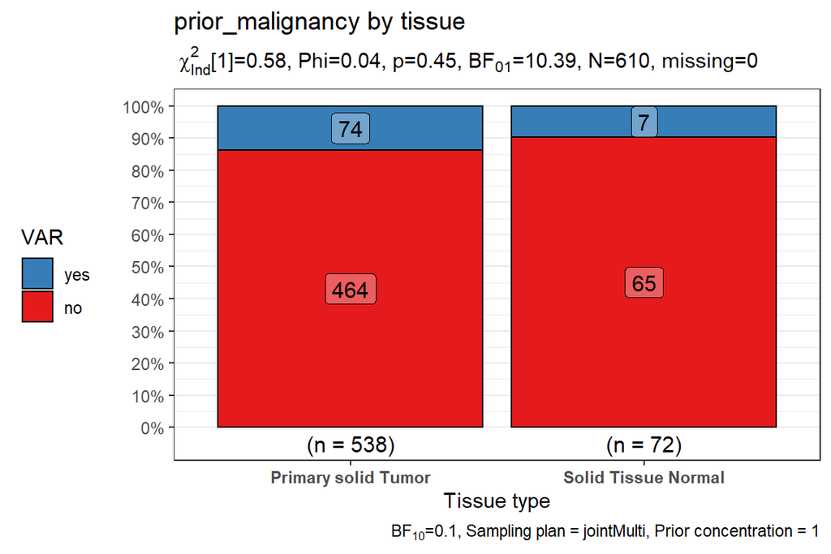

```r
discrete_vars <- c("is_ffpe",
                         "gender",
                         "ajcc_pathologic_stage",
                         "prior_treatment",
                         "race",
                   "prior_malignancy")

prop_viewer <- function(VAR) {
  PlotXTabs2(
    data = as_tibble(KIRC_data@colData),
    y = VAR,
    x = definition,
    bf.details = TRUE,
    xlab = "Tissue type",
    ylab = NULL,
    data.label = "counts",
    label.fill.alpha = .3,
    legend.position = "left",
    title = paste(VAR, "by tissue"),
    palette = "Set1"
  )   }

map(discrete_vars, ~ prop_viewer(.x))
```

Assessment: ajcc_pathologic_stage is signficantly different between tumor & NAT, and should be corrected for in the final limma model. Gender will also be corrected for, due to male-female genetic distance.

Create preliminary design matrix comparing sample groups “Solid Tissue Normal” to “Primary solid Tumor”

```r
targets <- KIRC_data@colData %>% as_tibble %>%
  mutate(ajcc_pathologic_stage = case_when(          # make cancer stage data a continuous & quantitative variable
    ajcc_pathologic_stage == "Stage I" ~ 1,
    ajcc_pathologic_stage == "Stage II" ~ 2,
    ajcc_pathologic_stage == "Stage III" ~ 3,
    ajcc_pathologic_stage == "Stage IV" ~ 4,
    TRUE ~ 2
))

group <- "definition"
comparison_groups <- KIRC_data@colData$definition %>% unique                 # set comparison groups
design_factor = colData(KIRC_data)[, group, drop=T]                          # choose design factor
design_factor <- factor(
    x = design_factor,
    levels=c("Solid Tissue Normal", "Primary solid Tumor")                   # Set first item here is the reference
)

design <- model.matrix(~ design_factor + gender + ajcc_pathologic_stage, targets)
```

Create DGEList object (S4) that contains counts, norm counts and lib sizes

```r
dge = DGEList(counts=assay(KIRC_data),
              samples=colData(KIRC_data),
              genes=as.data.frame(rowData(KIRC_data)))
```

Remove low expressed genes

```r
keep <- filterByExpr(dge, design)       # output is a gene list
dge <- dge[keep,,keep.lib.sizes=FALSE]
dge %>% str(., max.level = 3)
```

```
## Formal class 'DGEList' [package "edgeR"] with 1 slot
##   ..@ .Data:List of 3
##   .. ..$ : num [1:27541, 1:610] 4850 26 1534 1003 307 ...
##   .. .. ..- attr(*, "dimnames")=List of 2
##   .. ..$ :'data.frame':  610 obs. of  72 variables:
##   .. ..$ :'data.frame':  27541 obs. of  3 variables:
##   ..$ names: chr [1:3] "counts" "samples" "genes"
```

#### C) VOOM NEEDED?

Plot library sizes, normalization factors, and distributions to look for any data abnormalities (ie samples w/ poor sequencing or biological coverage)

Decide whether or not VOOM us necessary here (VOOM useful were lib size variance is high) by plotting library sizes

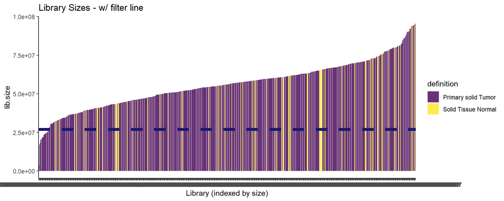

```r
lib_size_cut = 2.7*10^7   # size cutoff used to filter samples for a subsequent query below

(p.ls <- dge[[2]] %>%
  as_tibble(rownames = "library") %>%
  ggplot(., aes(fct_reorder(library, lib.size), lib.size)) +
  geom_bar(stat = "identity", fun = "mean", aes(fill = definition), alpha = 0.8, show.legend = TRUE) +
  labs(title = "Library Sizes - w/ filter line", x = "Library (indexed by size)") +
  theme_classic() +
  scale_fill_viridis_d() +
    geom_hline(yintercept = lib_size_cut, linetype = "dashed", size = 2, color = "midnightblue")
  )
```

```r
larger_libraries <- dge[[2]] %>%     # list of barcodes for larger libs
  dplyr::filter(lib.size > lib_size_cut) %>%
  rownames()
```

Scale normalization of the RNAseq read counts using TMM (trimmed mean of M component) normalization method.

```r
dge <- calcNormFactors(dge)
```

Plot library normalization factors

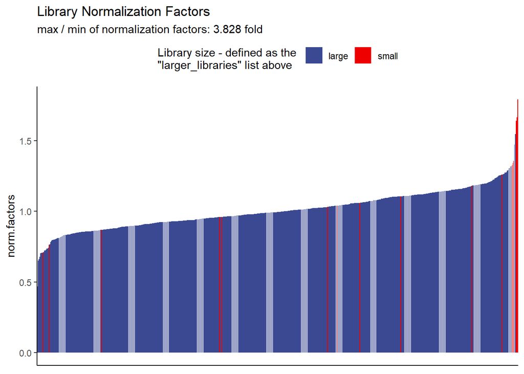

```r
(p.norm <- dge[[2]] %>%
  as_tibble(rownames = "library") %>%
  ggplot(., aes(fct_reorder(library, norm.factors), norm.factors)) +
  geom_bar(stat = "identity", fun = "mean", aes(fill = ifelse(library %in% larger_libraries, "large", "small")), show.legend = TRUE) +
  labs(title = "Library Normalization Factors", x = NULL,
       subtitle = paste("max / min of normalization factors:", round(max(dge[[2]]$norm.factors)/min(dge[[2]]$norm.factors) , 3), "fold" ),
       fill = "Library size - defined as the \n\"larger_libraries\" list above") +
  theme_classic() +
  theme(#axis.text.x = element_text(angle = 45, hjust = 1)
     #axis.title.x=element_blank(),
        axis.text.x=element_blank(),
        axis.ticks.x=element_blank(),
     legend.position = "top") +
   scale_fill_aaas())
```

Plot library expression distributions

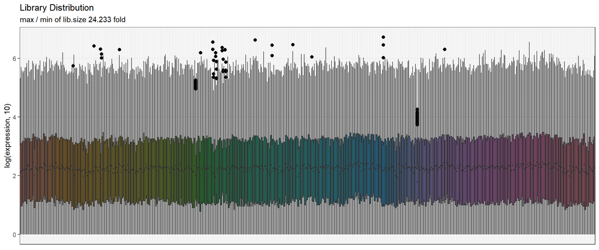

```r
(p.ld <- dge[[1]] %>%
  as_tibble(rownames = "geneID") %>%
  pivot_longer(-geneID,
               names_to = "library",
               values_to = "expression") %>%
  ggplot(., aes(`library`, log(`expression`, 10))) +
  geom_boxplot(outlier.colour="black",
               outlier.shape=16,
               outlier.size=2,
               notch=TRUE,
               aes(fill = library), show.legend = FALSE) +
  labs(title = "Library Distribution",
       x = NULL,
       subtitle = paste("max / min of lib.size",
                        round(max(dge[[2]]$lib.size)/min(dge[[2]]$lib.size), 3), "fold" )) +
  theme(#axis.text.x = element_text(angle = 45, hjust = 1)
        axis.title.x=element_blank(),
        axis.text.x=element_blank(),
        axis.ticks.x=element_blank()
       ))
```

### Analysis Stage 2 - Re-do GDC query, preparation, & normalization using a new filtered sample list (samples with larger library sizes). Then set up a survival model to find genes the predict survival.

So far…

A GDC query and download was done to visualize the metadata and plan the design matrix. The library sizes and normalization factors were plotted to find outliers and list excluding very small libraries was created. Metadata was also visualized to identify potential confounders that should be corrected for in the final voom/limma model below.

Next…

The query will be set up again, this time with specific barcodes (ie samples) that have been selected on the basis of having a larger library size. Design matrix and normalization factors are computed again to ensure compatibility with the new query.

#### D) RE-RUN QUERY

```r
larger_libraries %>% length   # list of barcodes used to select larger libraries
```

```
## [1] 593
```

```r
query_filtered = GDCquery(
  project = "TCGA-KIRC",
  data.category = "Transcriptome Profiling", # parameter enforced by GDCquery
  experimental.strategy = "RNA-Seq",
  workflow.type = "HTSeq - Counts",
  sample.type = c("Primary Tumor", "Solid Tissue Normal"),
  access = "open",
  legacy = FALSE,
  barcode = larger_libraries                       # the filter "larger_librararies" is now added in an otherwise identical query
  )

# Re_create expression matrix
KIRC_data <- GDCprepare(query_filtered,
                        directory = target_directory)
```

[output not shown]

[output cut: 540 more lines]

[output not shown]

```r
clinical <- KIRC_data@colData %>% as_tibble %>%
  mutate(ajcc_pathologic_stage = case_when(          # make cancer stage data a continuous & quantitative variable
    ajcc_pathologic_stage == "Stage I" ~ 1,
    ajcc_pathologic_stage == "Stage II" ~ 2,
    ajcc_pathologic_stage == "Stage III" ~ 3,
    ajcc_pathologic_stage == "Stage IV" ~ 4,
    TRUE ~ 2
))

group <- "definition"
comparison_groups <- KIRC_data@colData[[group]] %>% unique                   # set comparison groups
design_factor = colData(KIRC_data)[, group, drop=T]                          # choose design factor
design_factor <- factor(
    x = design_factor,
    levels=c("Solid Tissue Normal", "Primary solid Tumor")                   # Set first item here is the reference
)

design <- model.matrix(~ design_factor + gender + ajcc_pathologic_stage, clinical)

dge = DGEList(counts=assay(KIRC_data),  # CREATE S4 OBJECT
              samples=colData(KIRC_data),
              genes=as.data.frame(rowData(KIRC_data)))

keep <- filterByExpr(dge, design)       # output is a gene list

dge <- dge[keep,,keep.lib.sizes=FALSE]  # REMOVE LOW EXPRESSED GENES

dge <- calcNormFactors(dge)             # NORMALIZE

dge$counts %>% dim
```

```
## [1] 27362   593
```